# Objective

To identify different segments in the existing customer based on their spending patterns as well as past interaction with the bank.

## Import Libraries

```python
import warnings
warnings.filterwarnings('ignore')
```

```python
%matplotlib inline
import numpy as np
import pandas as pd
import matplotlib.pyplot as plt
import seaborn as sns
from scipy.stats import zscore
from sklearn.cluster import KMeans
from sklearn.cluster import AgglomerativeClustering
from sklearn.metrics import silhouette_score
from scipy.cluster.hierarchy import cophenet, dendrogram, linkage
from scipy.spatial.distance import pdist
from scipy.spatial.distance import cdist
```

## Import Dataset

```python
# Read the file
df=pd.read_excel('Credit Card Customer Data.xlsx')
```

## EDA

```python
df.info()       # Info about dataframe, columns, data types, Null values
```

```
<class 'pandas.core.frame.DataFrame'>
RangeIndex: 660 entries, 0 to 659
Data columns (total 7 columns):
 #   Column               Non-Null Count  Dtype
---  ------               --------------  -----
 0   Sl_No                660 non-null    int64
 1   Customer Key         660 non-null    int64
 2   Avg_Credit_Limit     660 non-null    int64
 3   Total_Credit_Cards   660 non-null    int64
 4   Total_visits_bank    660 non-null    int64
 5   Total_visits_online  660 non-null    int64
 6   Total_calls_made     660 non-null    int64
dtypes: int64(7)
memory usage: 36.2 KB
```

```python
df.head()                                          # First five rows
```

|  | Sl_No | Customer Key | Avg_Credit_Limit | Total_Credit_Cards | Total_visits_bank | Total_visits_online | Total_calls_made |
| --- | --- | --- | --- | --- | --- | --- | --- |
| 0 | 1 | 87073 | 100000 | 2 | 1 | 1 | 0 |
| 1 | 2 | 38414 | 50000 | 3 | 0 | 10 | 9 |
| 2 | 3 | 17341 | 50000 | 7 | 1 | 3 | 4 |
| 3 | 4 | 40496 | 30000 | 5 | 1 | 1 | 4 |
| 4 | 5 | 47437 | 100000 | 6 | 0 | 12 | 3 |

```python
df.tail()                                          # Last five rows
```

|  | Sl_No | Customer Key | Avg_Credit_Limit | Total_Credit_Cards | Total_visits_bank | Total_visits_online | Total_calls_made |
| --- | --- | --- | --- | --- | --- | --- | --- |
| 655 | 656 | 51108 | 99000 | 10 | 1 | 10 | 0 |
| 656 | 657 | 60732 | 84000 | 10 | 1 | 13 | 2 |
| 657 | 658 | 53834 | 145000 | 8 | 1 | 9 | 1 |
| 658 | 659 | 80655 | 172000 | 10 | 1 | 15 | 0 |
| 659 | 660 | 80150 | 167000 | 9 | 0 | 12 | 2 |

```python
print('-----Number of Nulls-----')
df.isnull().sum()                                  # Check Null values
```

```
-----Number of Nulls-----
```

```
Sl_No                  0
Customer Key           0
Avg_Credit_Limit       0
Total_Credit_Cards     0
Total_visits_bank      0
Total_visits_online    0
Total_calls_made       0
dtype: int64
```

```python
print('-----Number of unique values-----')
df.nunique()                                       # Number of unique values in each column
```

```
-----Number of unique values-----
```

```
Sl_No                  660
Customer Key           655
Avg_Credit_Limit       110
Total_Credit_Cards      10
Total_visits_bank        6
Total_visits_online     16
Total_calls_made        11
dtype: int64
```

```python
print('Shape of the dataframe is:',df.shape)       # Shape of data frame
df.describe().transpose()                          # Statistical summary
```

```
Shape of the dataframe is: (660, 7)
```

|  | count | mean | std | min | 25% | 50% | 75% | max |
| --- | --- | --- | --- | --- | --- | --- | --- | --- |
| Sl_No | 660.0 | 330.500000 | 190.669872 | 1.0 | 165.75 | 330.5 | 495.25 | 660.0 |
| Customer Key | 660.0 | 55141.443939 | 25627.772200 | 11265.0 | 33825.25 | 53874.5 | 77202.50 | 99843.0 |
| Avg_Credit_Limit | 660.0 | 34574.242424 | 37625.487804 | 3000.0 | 10000.00 | 18000.0 | 48000.00 | 200000.0 |
| Total_Credit_Cards | 660.0 | 4.706061 | 2.167835 | 1.0 | 3.00 | 5.0 | 6.00 | 10.0 |
| Total_visits_bank | 660.0 | 2.403030 | 1.631813 | 0.0 | 1.00 | 2.0 | 4.00 | 5.0 |
| Total_visits_online | 660.0 | 2.606061 | 2.935724 | 0.0 | 1.00 | 2.0 | 4.00 | 15.0 |
| Total_calls_made | 660.0 | 3.583333 | 2.865317 | 0.0 | 1.00 | 3.0 | 5.00 | 10.0 |

- As we from above there are 7 columns.
- There are no null values.
- All the fields are integer
- The shape of data frame is 660 rows and 7 columns
- The mean credit limit is 34574
- The mean number of credit cards a customer has is around 5
- The mean number of vistis a customer makes to bank is around 2.4
- The mean number of online visits for a customer is around 3
- And the mean number of calls made by a customer is around 3.6

```python
## Remove Sl_No and Customer Key (which is just an ID) since they are redundant and seems irrelevant
df.drop('Sl_No', axis=1, inplace=True)
df.drop('Customer Key', axis=1, inplace=True)
```

##### Plot boxplots to visualize data

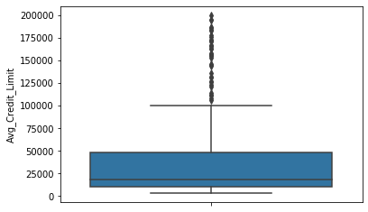

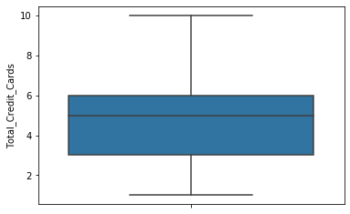

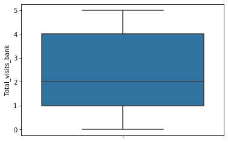

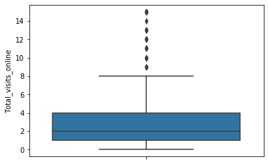

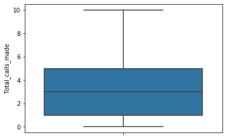

```python
for i in df.columns:
    sns.boxplot(y=df[i])
    plt.show()
```

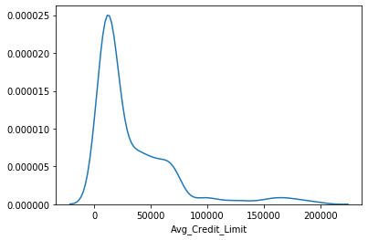

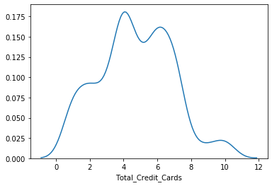

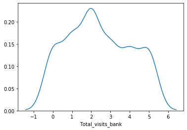

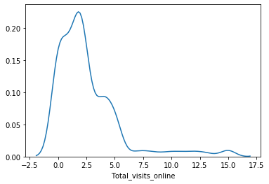

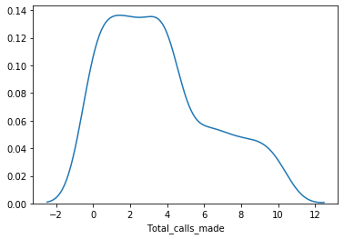

```python
for i in df.columns:
    sns.distplot(df[i],hist=False,)
    plt.show()
```

From the plots above, we see data for average credit limit and total visits online is right skewed and majorly there are around 4 or more clusters.

```python
## Scale the data
df_z = df.apply(zscore)
```

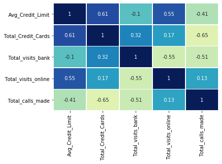

```python
sns.heatmap(df_z.corr(),
            annot=True,
            linewidths=.5,
            center=0,
            cbar=False,
            cmap="YlGnBu")

plt.show();
```

- From the map above, we see that there is some +ve corelation between total number of credit cards and average credit limit which is understandable.
- We also see that there are more online visits if credit limit is higher
- We see that there is -ve corelation between total number of cards/average credit/total visits to bank and total calls made

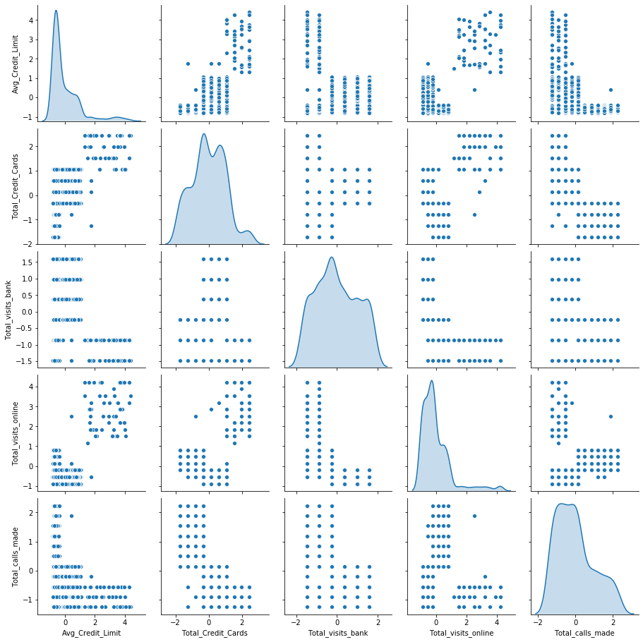

```python
sns.pairplot(df_z, diag_kind='kde');
```

Again from the plot above, we see majorly around 4 clusters

## K Means Clustering

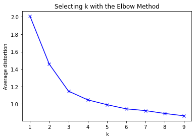

```python
# Finding optimal no. of clusters
clusters=range(1,10)
meanDistortions=[]

for k in clusters:
    model=KMeans(n_clusters=k)
    model.fit(df_z)
    prediction=model.predict(df_z)
    meanDistortions.append(sum(np.min(cdist(df_z, model.cluster_centers_, 'euclidean'), axis=1)) / df
                           .shape[0])

plt.plot(clusters, meanDistortions, 'bx-')
plt.xlabel('k')
plt.ylabel('Average distortion')
plt.title('Selecting k with the Elbow Method')
```

```python
# From the elbow plot above, we infer optimal clusters as 3 as this is the point where elbow of the plot curves.
# Hence, set the value of k=3
kmeans = KMeans(n_clusters=3, n_init = 15, random_state=12)
```

```python
kmeans.fit(df_z)
```

```
KMeans(algorithm='auto', copy_x=True, init='k-means++', max_iter=300,
       n_clusters=3, n_init=15, n_jobs=None, precompute_distances='auto',
       random_state=12, tol=0.0001, verbose=0)
```

```python
predict = kmeans.predict(df_z)
```

```python
df_KMeans = df.copy()
df_KMeans_z = df_z.copy()
df_KMeans['Group'] = predict
df_KMeans_z['Group'] = predict
```

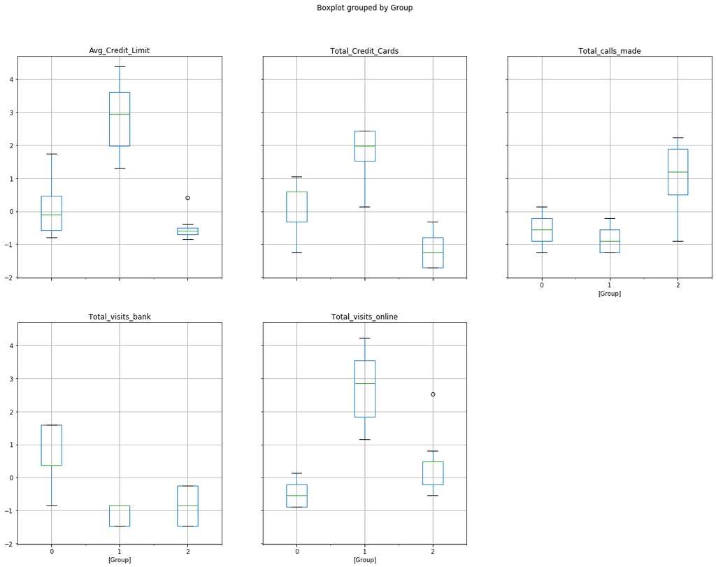

```python
df_KMeans_z.boxplot(by='Group', layout = (2,3), figsize=(20,15));
```

As we above most of the custers are distinct

```python
silhouette_avg_KMeans = silhouette_score(df_z, predict)
```

```python
df_KMeans_clust = df_KMeans.groupby(['Group'])
df_KMeans_clust.mean()
```

| Group | Avg_Credit_Limit | Total_Credit_Cards | Total_visits_bank | Total_visits_online | Total_calls_made |
| --- | --- | --- | --- | --- | --- |
| 0 | 33782.383420 | 5.515544 | 3.489637 | 0.981865 | 2.000000 |
| 1 | 141040.000000 | 8.740000 | 0.600000 | 10.900000 | 1.080000 |
| 2 | 12174.107143 | 2.410714 | 0.933036 | 3.553571 | 6.870536 |

```python
resultsDf = pd.DataFrame({'Method':['K Means'], 'Silhouette Score': silhouette_avg_KMeans},index={'1'})
resultsDf = resultsDf[['Method', 'Silhouette Score']]
resultsDf
```

|  | Method | Silhouette Score |
| --- | --- | --- |
| 1 | K Means | 0.515718 |

A silhouette score closer to 1 is better, here it is .52 which is not too bad.

## Hierarchical Clustering

```python
## Execute hierarchical clustering with different linkages and keep number of clusters as 3
model_average = AgglomerativeClustering(n_clusters=3, affinity='euclidean',  linkage='average')
model_ward = AgglomerativeClustering(n_clusters=3, affinity='euclidean', linkage='ward')
model_complete = AgglomerativeClustering(n_clusters=3, affinity='euclidean', linkage='complete')
model_single = AgglomerativeClustering(n_clusters=3, affinity='euclidean', linkage='single')
```

```python
predict_hir_av = model_average.fit_predict(df_z)
predict_hir_wa = model_ward.fit_predict(df_z)
predict_hir_cm = model_complete.fit_predict(df_z)
predict_hir_si = model_single.fit_predict(df_z)
```

```python
df_hir_av = df.copy()
df_hir_av_z = df_z.copy()
df_hir_av['Group'] = model_average.labels_
df_hir_av_z['Group'] = model_average.labels_

silhouette_avg_Hierarchial_av = silhouette_score(df_z,predict_hir_av,metric='euclidean')
tempResultsDf = pd.DataFrame({'Method':['Hierarchical clustering (Average)'], 'Silhouette Score': [silhouette_avg_Hierarchial_av]},index={'2'})
resultsDf = pd.concat([resultsDf, tempResultsDf])
resultsDf = resultsDf[['Method', 'Silhouette Score']]

##

df_hir_wa = df.copy()
df_hir_wa_z = df_z.copy()
df_hir_wa['Group'] = model_ward.labels_
df_hir_wa_z['Group'] = model_ward.labels_

silhouette_avg_Hierarchial_wa = silhouette_score(df_z,predict_hir_wa,metric='euclidean')
tempResultsDf = pd.DataFrame({'Method':['Hierarchical clustering (Ward)'], 'Silhouette Score': [silhouette_avg_Hierarchial_wa]},index={'3'})
resultsDf = pd.concat([resultsDf, tempResultsDf])
resultsDf = resultsDf[['Method', 'Silhouette Score']]

##

df_hir_cm = df.copy()
df_hir_cm_z = df_z.copy()
df_hir_cm['Group'] = model_complete.labels_
df_hir_cm_z['Group'] = model_complete.labels_

silhouette_avg_Hierarchial_cm = silhouette_score(df_z,predict_hir_cm,metric='euclidean')
tempResultsDf = pd.DataFrame({'Method':['Hierarchical clustering (Complete)'], 'Silhouette Score': [silhouette_avg_Hierarchial_cm]},index={'4'})
resultsDf = pd.concat([resultsDf, tempResultsDf])
resultsDf = resultsDf[['Method', 'Silhouette Score']]

##

df_hir_si = df.copy()
df_hir_si_z = df_z.copy()
df_hir_si['Group'] = model_single.labels_
df_hir_si_z['Group'] = model_single.labels_

silhouette_avg_Hierarchial_si = silhouette_score(df_z,predict_hir_si,metric='euclidean')
tempResultsDf = pd.DataFrame({'Method':['Hierarchical clustering (Single)'], 'Silhouette Score': [silhouette_avg_Hierarchial_si]},index={'5'})
resultsDf = pd.concat([resultsDf, tempResultsDf])
resultsDf = resultsDf[['Method', 'Silhouette Score']]
```

#### Group data based on clustering done and the mean values for each of linkage method

```python
df_hir_av_clust = df_hir_av.groupby(['Group'])
df_hir_av_clust.mean()
```

| Group | Avg_Credit_Limit | Total_Credit_Cards | Total_visits_bank | Total_visits_online | Total_calls_made |
| --- | --- | --- | --- | --- | --- |
| 0 | 33713.178295 | 5.511628 | 3.485788 | 0.984496 | 2.005168 |
| 1 | 141040.000000 | 8.740000 | 0.600000 | 10.900000 | 1.080000 |
| 2 | 12197.309417 | 2.403587 | 0.928251 | 3.560538 | 6.883408 |

```python
df_hir_wa_clust = df_hir_wa.groupby(['Group'])
df_hir_wa_clust.mean()
```

| Group | Avg_Credit_Limit | Total_Credit_Cards | Total_visits_bank | Total_visits_online | Total_calls_made |
| --- | --- | --- | --- | --- | --- |
| 0 | 33851.948052 | 5.516883 | 3.493506 | 0.979221 | 1.994805 |
| 1 | 12151.111111 | 2.422222 | 0.937778 | 3.546667 | 6.857778 |
| 2 | 141040.000000 | 8.740000 | 0.600000 | 10.900000 | 1.080000 |

```python
df_hir_cm_clust = df_hir_cm.groupby(['Group'])
df_hir_cm_clust.mean()
```

| Group | Avg_Credit_Limit | Total_Credit_Cards | Total_visits_bank | Total_visits_online | Total_calls_made |
| --- | --- | --- | --- | --- | --- |
| 0 | 33151.133501 | 5.460957 | 3.405542 | 1.010076 | 2.060453 |
| 1 | 141040.000000 | 8.740000 | 0.600000 | 10.900000 | 1.080000 |
| 2 | 12234.741784 | 2.352113 | 0.957746 | 3.633803 | 7.009390 |

```python
df_hir_si_clust = df_hir_si.groupby(['Group'])
df_hir_si_clust.mean()
```

| Group | Avg_Credit_Limit | Total_Credit_Cards | Total_visits_bank | Total_visits_online | Total_calls_made |
| --- | --- | --- | --- | --- | --- |
| 0 | 25807.881773 | 4.377668 | 2.555008 | 1.912972 | 3.779967 |
| 1 | 50000.000000 | 3.000000 | 0.000000 | 10.000000 | 9.000000 |
| 2 | 141040.000000 | 8.740000 | 0.600000 | 10.900000 | 1.080000 |

As we see above, different linkages give different mean values

#### Boxplots to visualize the clusters for each of linkages

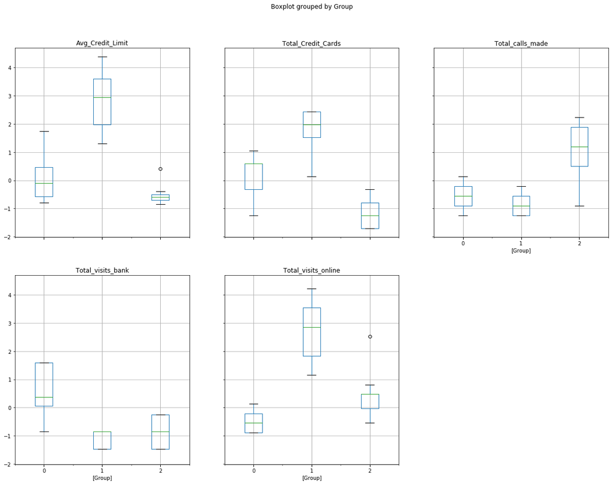

```python
df_hir_av_z.boxplot(by='Group', layout = (2,3), figsize=(20,15));
```

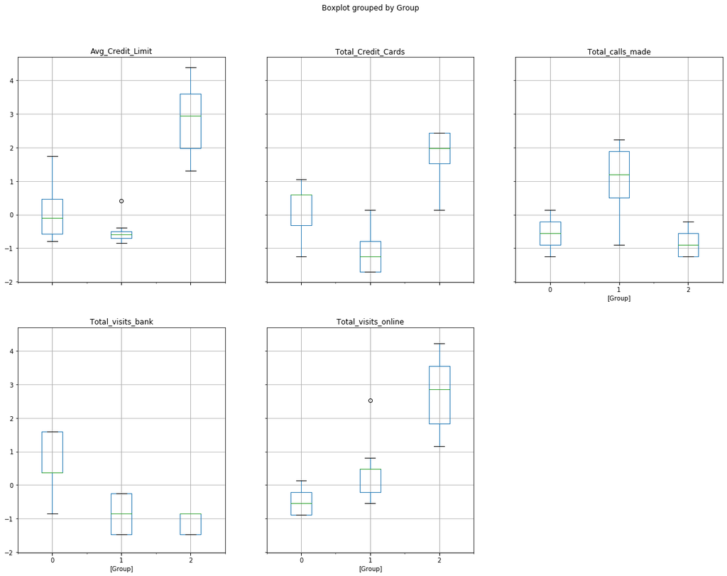

```python
df_hir_wa_z.boxplot(by='Group', layout = (2,3), figsize=(20,15));
```

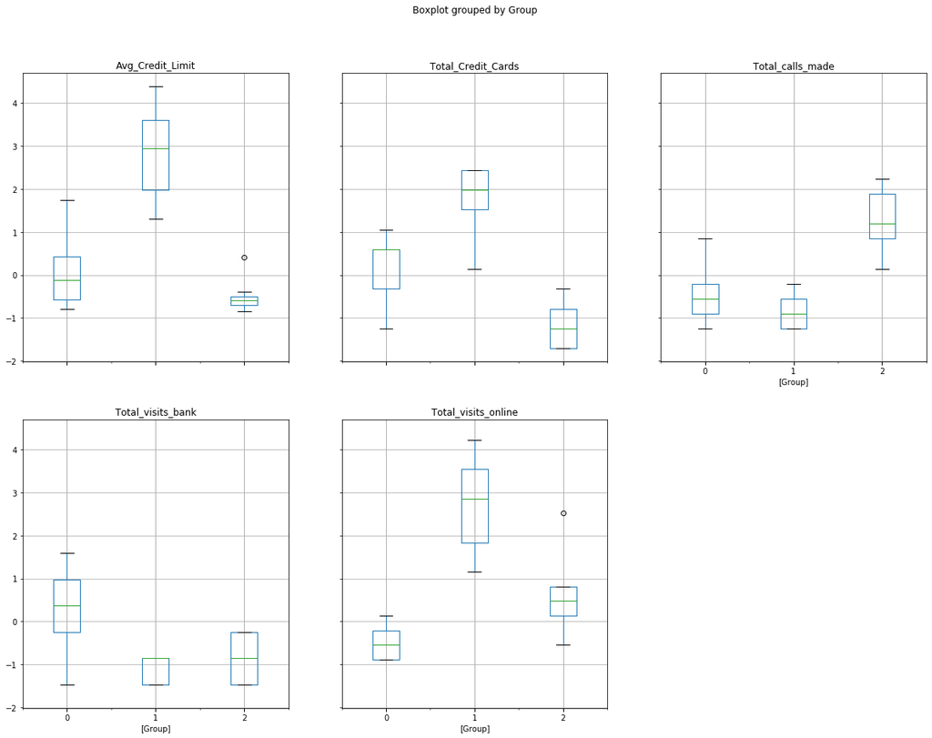

```python
df_hir_cm_z.boxplot(by='Group', layout = (2,3), figsize=(20,15));
```

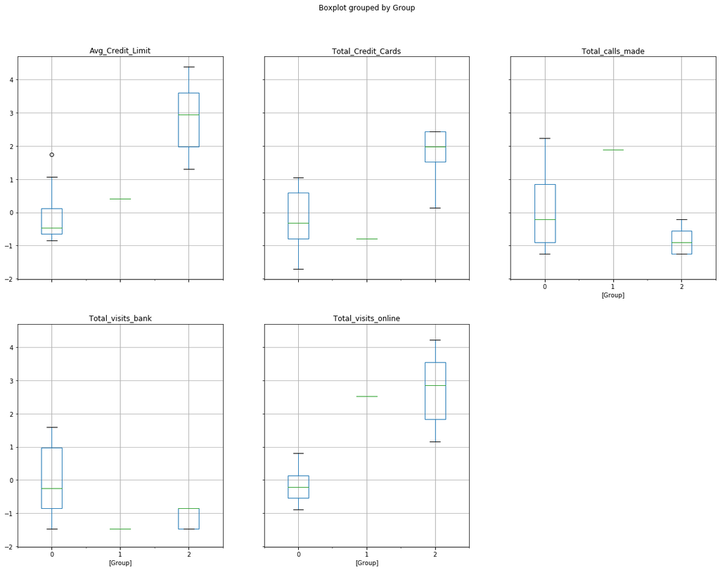

```python
df_hir_si_z.boxplot(by='Group', layout = (2,3), figsize=(20,15));
```

In the boxplots above, we see that clusters are created distinct for each of linkage method.

#### Let's check the cophenetic coefficient and plot dendograms

```python
# cophenet index is a measure of the correlation between the distance of points in feature space and distance on dendrogram
# closer it is to 1, the better is the clustering

Z = linkage(df_z, metric='euclidean', method='average')
c, coph_dists = cophenet(Z , pdist(df_z))

c
```

```
0.8977080867389372
```

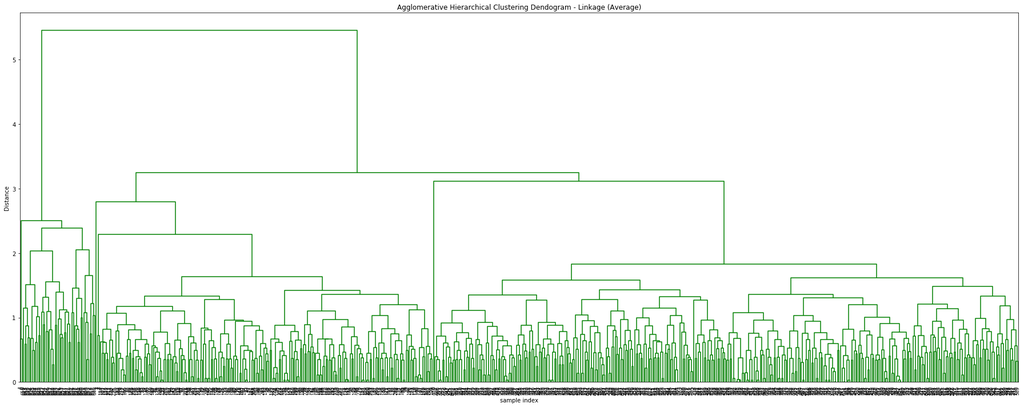

```python
plt.figure(figsize=(25, 10))
plt.title('Agglomerative Hierarchical Clustering Dendogram - Linkage (Average)')
plt.xlabel('sample index')
plt.ylabel('Distance')
dendrogram(Z, leaf_rotation=90.,color_threshold = 40, leaf_font_size=8. )
plt.tight_layout()
```

```python
# cophenet index is a measure of the correlation between the distance of points in feature space and distance on dendrogram
# closer it is to 1, the better is the clustering

Z = linkage(df_z, metric='euclidean', method='complete')
c, coph_dists = cophenet(Z , pdist(df_z))

c
```

```
0.8599730607972423
```

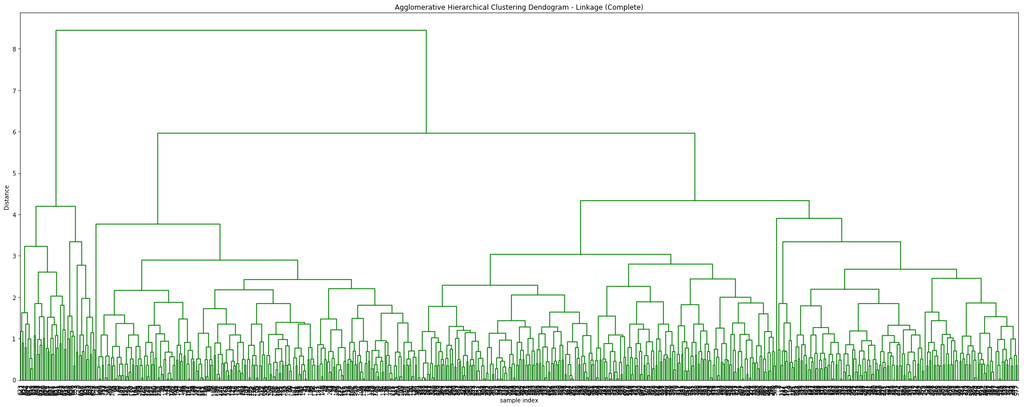

```python
plt.figure(figsize=(25, 10))
plt.title('Agglomerative Hierarchical Clustering Dendogram - Linkage (Complete)')
plt.xlabel('sample index')
plt.ylabel('Distance')
dendrogram(Z, leaf_rotation=90.,color_threshold=90,  leaf_font_size=10. )
plt.tight_layout()
```

```python
# cophenet index is a measure of the correlation between the distance of points in feature space and distance on dendrogram
# closer it is to 1, the better is the clustering

Z = linkage(df_z, metric='euclidean', method='ward')
c, coph_dists = cophenet(Z , pdist(df_z))

c
```

```
0.7415156284827493
```

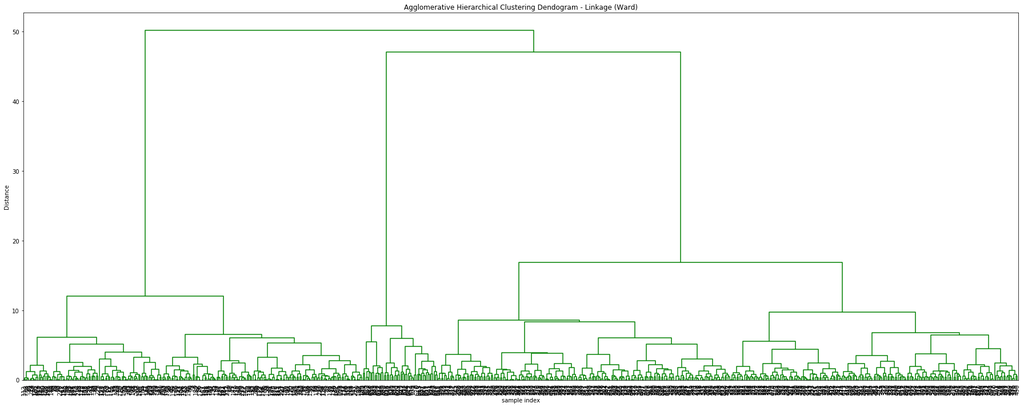

```python
plt.figure(figsize=(25, 10))
plt.title('Agglomerative Hierarchical Clustering Dendogram - Linkage (Ward)')
plt.xlabel('sample index')
plt.ylabel('Distance')
dendrogram(Z, leaf_rotation=90.,color_threshold=600,  leaf_font_size=10. )
plt.tight_layout()
```

```python
# cophenet index is a measure of the correlation between the distance of points in feature space and distance on dendrogram
# closer it is to 1, the better is the clustering

Z = linkage(df_z, metric='euclidean', method='single')
c, coph_dists = cophenet(Z , pdist(df_z))

c
```

```
0.7391220243806552
```

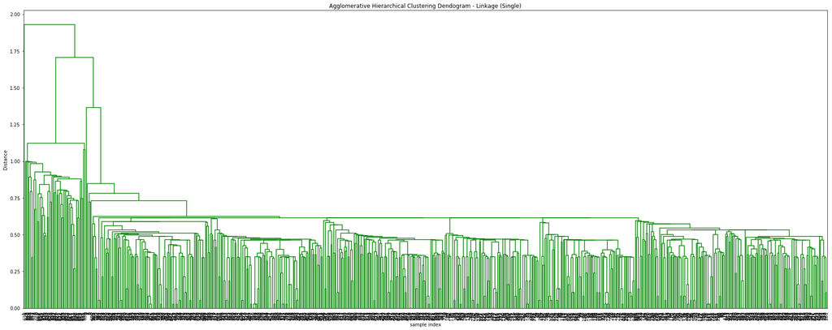

```python
plt.figure(figsize=(25, 10))
plt.title('Agglomerative Hierarchical Clustering Dendogram - Linkage (Single)')
plt.xlabel('sample index')
plt.ylabel('Distance')
dendrogram(Z, leaf_rotation=90.,color_threshold=600,  leaf_font_size=10. )
plt.tight_layout()
```

#### We see that average linkage gives the best value of cophenetic coefficient of .89 across all linkage methods

```python
resultsDf
```

|  | Method | Silhouette Score |
| --- | --- | --- |
| 1 | K Means | 0.515718 |
| 2 | Hierarchical clustering (Average) | 0.515922 |
| 3 | Hierarchical clustering (Ward) | 0.514764 |
| 4 | Hierarchical clustering (Complete) | 0.502644 |
| 5 | Hierarchical clustering (Single) | 0.374289 |

#### Compare KMeans and Hierarchical clustering

```python
df_compare = df.copy()
df_compare['KMeans Group'] = df_KMeans['Group']
df_compare['Hierarchical Group'] = df_hir_av['Group']
df_compare['Compare'] = np.where(df_compare['KMeans Group'] == df_compare['Hierarchical Group'], 'True', 'False')
df_compare[df_compare['Compare']=='False']
```

|  | Avg_Credit_Limit | Total_Credit_Cards | Total_visits_bank | Total_visits_online | Total_calls_made | KMeans Group | Hierarchical Group | Compare |
| --- | --- | --- | --- | --- | --- | --- | --- | --- |
| 313 | 7000 | 4 | 2 | 2 | 4 | 2 | 0 | False |

On comparison both K Means Clustering and Hierarchical clustering with average linkage give the similar Silhouette score. We find only one record which has been grouped/placed in a different cluster when both KMeans and Hierarchical Clustering with average linkage are compared.

```python
print('KMeans Cluster Analysis')
df_KMeans_clust.mean()
```

```
KMeans Cluster Analysis
```

| Group | Avg_Credit_Limit | Total_Credit_Cards | Total_visits_bank | Total_visits_online | Total_calls_made |
| --- | --- | --- | --- | --- | --- |
| 0 | 33782.383420 | 5.515544 | 3.489637 | 0.981865 | 2.000000 |
| 1 | 141040.000000 | 8.740000 | 0.600000 | 10.900000 | 1.080000 |
| 2 | 12174.107143 | 2.410714 | 0.933036 | 3.553571 | 6.870536 |

```python
print('Hierarchical Cluster Analysis')
df_hir_av_clust.mean()
```

```
Hierarchical Cluster Analysis
```

| Group | Avg_Credit_Limit | Total_Credit_Cards | Total_visits_bank | Total_visits_online | Total_calls_made |
| --- | --- | --- | --- | --- | --- |
| 0 | 33713.178295 | 5.511628 | 3.485788 | 0.984496 | 2.005168 |
| 1 | 141040.000000 | 8.740000 | 0.600000 | 10.900000 | 1.080000 |
| 2 | 12197.309417 | 2.403587 | 0.928251 | 3.560538 | 6.883408 |

#### 1. How many different segments of customers are there?

As we see above, we have three different segments of customers based on their average credit limit.

#### 2. How are these segments different from each other?

These segments mainly differ based on credit limits as below.

1) High Credit Limit

2) Medium Credit Limit

3) Low Credit Limit

Customers who have high credit limit seems to be high spenders with more number of credit cards (mean value is around 9) and they prefer to bank online rather visiting the bank or calling bank

Customers who have low credit limit have less number of credit cards (which is understandable) and have more calls made to the bank

Customers with medium credit limit have more credit cards when compared to low credit customers and have less calls made to bank as compared to low credit customers but have more visits to bank overall

#### 3. What are your recommendations to the bank on how to better market to and service these customers?

As we see there are three (3) categories/segments of customers with each segment having a preference for communication channel with bank, it is recommended that products are marketed to specific segment of customers through their preferred channel. Also, additional services can be provided based on how they connect with bank and also based on their spending pattern which can deduced from average credit limit.

Based on how bank wants to promote its products and services, a segment of customers can be targeted as we know their channel of preference.